# Report of Current Strategies executed by Devin McMurrey since August 2021

```python
import matplotlib.pyplot as plt

%matplotlib inline

import pandas as pd
import seaborn as sns

import numpy as np


FILE_PATH = "C:\CIL\CSV"
sales_report = open(FILE_PATH + '\sales_report.csv')

df_sales = pd.read_csv(sales_report)

df_sales= pd.DataFrame(df_sales)
#display(df_sales)
x = pd.crosstab(df_sales.Source_of_lead, df_sales.Ultimate_end_Result_)
y = pd.crosstab(df_sales.Source_of_lead, df_sales.Ultimate_end_Result_, margins=True, margins_name = "Total")

display(x)
display(y)
```

| Ultimate_end_Result_ Source_of_lead | 1_meeting | 2_meetings_ | 3_meetings_ | 4_meetings_ | exchange_correspondence_ | limited_correspondence_ | never_answered_ | not_interested | open_to_meeting_ |
| --- | --- | --- | --- | --- | --- | --- | --- | --- | --- |
| Devin_network | 3 | 0 | 0 | 0 | 2 | 0 | 1 | 0 | 0 |
| LinkedIn_Lean_Startup | 0 | 0 | 0 | 0 | 0 | 0 | 2 | 0 | 0 |
| Meetup_lean_start_up | 0 | 0 | 0 | 0 | 0 | 1 | 7 | 0 | 0 |
| Oranic_Linkedin | 0 | 1 | 0 | 0 | 0 | 0 | 2 | 0 | 0 |
| Private_Equity_Firm | 0 | 0 | 0 | 0 | 0 | 0 | 9 | 0 | 1 |
| crunchbase_ | 9 | 7 | 5 | 0 | 4 | 1 | 94 | 3 | 0 |
| facebook_ | 0 | 0 | 0 | 1 | 0 | 0 | 0 | 0 | 0 |
| reddit | 0 | 0 | 1 | 0 | 0 | 0 | 0 | 0 | 0 |

| Ultimate_end_Result_ Source_of_lead | 1_meeting | 2_meetings_ | 3_meetings_ | 4_meetings_ | exchange_correspondence_ | limited_correspondence_ | never_answered_ | not_interested | open_to_meeting_ | Total |
| --- | --- | --- | --- | --- | --- | --- | --- | --- | --- | --- |
| Devin_network | 3 | 0 | 0 | 0 | 2 | 0 | 1 | 0 | 0 | 6 |
| LinkedIn_Lean_Startup | 0 | 0 | 0 | 0 | 0 | 0 | 2 | 0 | 0 | 2 |
| Meetup_lean_start_up | 0 | 0 | 0 | 0 | 0 | 1 | 7 | 0 | 0 | 8 |
| Oranic_Linkedin | 0 | 1 | 0 | 0 | 0 | 0 | 2 | 0 | 0 | 3 |
| Private_Equity_Firm | 0 | 0 | 0 | 0 | 0 | 0 | 9 | 0 | 1 | 10 |
| crunchbase_ | 9 | 7 | 5 | 0 | 4 | 1 | 94 | 3 | 0 | 123 |
| facebook_ | 0 | 0 | 0 | 1 | 0 | 0 | 0 | 0 | 0 | 1 |
| reddit | 0 | 0 | 1 | 0 | 0 | 0 | 0 | 0 | 0 | 1 |
| Total | 12 | 8 | 6 | 1 | 6 | 2 | 115 | 3 | 1 | 154 |

### above cross tab shows actual count of each prospect and where they were found

```python
pd.crosstab(df_sales.Source_of_lead, df_sales.Ultimate_end_Result_, margins=True, margins_name = "Total", normalize = True).round(4)*100
```

| Ultimate_end_Result_ Source_of_lead | 1_meeting | 2_meetings_ | 3_meetings_ | 4_meetings_ | exchange_correspondence_ | limited_correspondence_ | never_answered_ | not_interested | open_to_meeting_ | Total |
| --- | --- | --- | --- | --- | --- | --- | --- | --- | --- | --- |
| Devin_network | 1.95 | 0.00 | 0.00 | 0.00 | 1.3 | 0.00 | 0.65 | 0.00 | 0.00 | 3.90 |
| LinkedIn_Lean_Startup | 0.00 | 0.00 | 0.00 | 0.00 | 0.0 | 0.00 | 1.30 | 0.00 | 0.00 | 1.30 |
| Meetup_lean_start_up | 0.00 | 0.00 | 0.00 | 0.00 | 0.0 | 0.65 | 4.55 | 0.00 | 0.00 | 5.19 |
| Oranic_Linkedin | 0.00 | 0.65 | 0.00 | 0.00 | 0.0 | 0.00 | 1.30 | 0.00 | 0.00 | 1.95 |
| Private_Equity_Firm | 0.00 | 0.00 | 0.00 | 0.00 | 0.0 | 0.00 | 5.84 | 0.00 | 0.65 | 6.49 |
| crunchbase_ | 5.84 | 4.55 | 3.25 | 0.00 | 2.6 | 0.65 | 61.04 | 1.95 | 0.00 | 79.87 |
| facebook_ | 0.00 | 0.00 | 0.00 | 0.65 | 0.0 | 0.00 | 0.00 | 0.00 | 0.00 | 0.65 |
| reddit | 0.00 | 0.00 | 0.65 | 0.00 | 0.0 | 0.00 | 0.00 | 0.00 | 0.00 | 0.65 |
| Total | 7.79 | 5.19 | 3.90 | 0.65 | 3.9 | 1.30 | 74.68 | 1.95 | 0.65 | 100.00 |

### above cross tab shows actual count of each prospect and where they were found expressed as % of total

```python
pd.crosstab(df_sales.Source_of_lead, df_sales.Ultimate_end_Result_, margins=True, margins_name = "Total", normalize = 'columns').round(4)*100
```

| Ultimate_end_Result_ Source_of_lead | 1_meeting | 2_meetings_ | 3_meetings_ | 4_meetings_ | exchange_correspondence_ | limited_correspondence_ | never_answered_ | not_interested | open_to_meeting_ | Total |
| --- | --- | --- | --- | --- | --- | --- | --- | --- | --- | --- |
| Devin_network | 25.0 | 0.0 | 0.00 | 0.0 | 33.33 | 0.0 | 0.87 | 0.0 | 0.0 | 3.90 |
| LinkedIn_Lean_Startup | 0.0 | 0.0 | 0.00 | 0.0 | 0.00 | 0.0 | 1.74 | 0.0 | 0.0 | 1.30 |
| Meetup_lean_start_up | 0.0 | 0.0 | 0.00 | 0.0 | 0.00 | 50.0 | 6.09 | 0.0 | 0.0 | 5.19 |
| Oranic_Linkedin | 0.0 | 12.5 | 0.00 | 0.0 | 0.00 | 0.0 | 1.74 | 0.0 | 0.0 | 1.95 |
| Private_Equity_Firm | 0.0 | 0.0 | 0.00 | 0.0 | 0.00 | 0.0 | 7.83 | 0.0 | 100.0 | 6.49 |
| crunchbase_ | 75.0 | 87.5 | 83.33 | 0.0 | 66.67 | 50.0 | 81.74 | 100.0 | 0.0 | 79.87 |
| facebook_ | 0.0 | 0.0 | 0.00 | 100.0 | 0.00 | 0.0 | 0.00 | 0.0 | 0.0 | 0.65 |
| reddit | 0.0 | 0.0 | 16.67 | 0.0 | 0.00 | 0.0 | 0.00 | 0.0 | 0.0 | 0.65 |

```python
pd.crosstab(df_sales.Source_of_lead, df_sales.Ultimate_end_Result_, margins=True, margins_name = "Total", normalize = 'index').round(4)*100
```

| Ultimate_end_Result_ Source_of_lead | 1_meeting | 2_meetings_ | 3_meetings_ | 4_meetings_ | exchange_correspondence_ | limited_correspondence_ | never_answered_ | not_interested | open_to_meeting_ |
| --- | --- | --- | --- | --- | --- | --- | --- | --- | --- |
| Devin_network | 50.00 | 0.00 | 0.00 | 0.00 | 33.33 | 0.00 | 16.67 | 0.00 | 0.00 |
| LinkedIn_Lean_Startup | 0.00 | 0.00 | 0.00 | 0.00 | 0.00 | 0.00 | 100.00 | 0.00 | 0.00 |
| Meetup_lean_start_up | 0.00 | 0.00 | 0.00 | 0.00 | 0.00 | 12.50 | 87.50 | 0.00 | 0.00 |
| Oranic_Linkedin | 0.00 | 33.33 | 0.00 | 0.00 | 0.00 | 0.00 | 66.67 | 0.00 | 0.00 |
| Private_Equity_Firm | 0.00 | 0.00 | 0.00 | 0.00 | 0.00 | 0.00 | 90.00 | 0.00 | 10.00 |
| crunchbase_ | 7.32 | 5.69 | 4.07 | 0.00 | 3.25 | 0.81 | 76.42 | 2.44 | 0.00 |
| facebook_ | 0.00 | 0.00 | 0.00 | 100.00 | 0.00 | 0.00 | 0.00 | 0.00 | 0.00 |
| reddit | 0.00 | 0.00 | 100.00 | 0.00 | 0.00 | 0.00 | 0.00 | 0.00 | 0.00 |
| Total | 7.79 | 5.19 | 3.90 | 0.65 | 3.90 | 1.30 | 74.68 | 1.95 | 0.65 |

## above cross tab illustrates what % each source was made up of each column. AKA what we did with the customers from that source (by row vs by collumn as seen above)

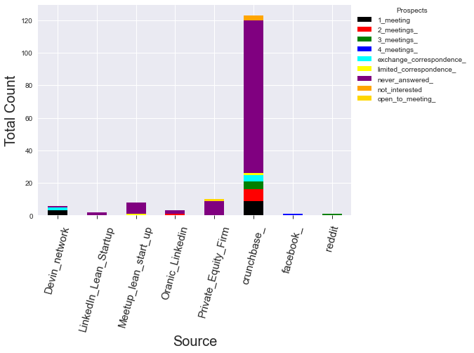

```python
plt.style.use('seaborn')
bp = x.plot(kind = "bar", stacked = True, rot=0, color=['black', 'red', 'green', 'blue', 'cyan', 'yellow','purple','orange','gold'])
bp.legend(title = "Prospects", bbox_to_anchor=(1, 1.02), loc = 'upper left')
bp.tick_params(axis = 'x', direction= 'out', length = 5, rotation =75, labelsize = 15)
bp.set_xlabel('Source', fontsize=20)
bp.set_ylabel('Total Count', fontsize= 20)
```

## Given these outcomes I would suggest a pivot to focus more on other areas of sourcing. Especially one group in particualr: P/E firms.

## My reccomendation is based on the following logic:

## 1. We have a similar method like crunchbase from which to pull these sources

## 2. The above process could be automated by a web scraper/parser that we can load each site into and pull contact information quickly

## 3. We can send a terse, direct email to these prosects that can more or less be exactly the same (automated) to each of the contacts we pull

## Ex: Hi [name], I represent a Venture Studio based in Chicago. We specialize in digital product innovation. Experience has demonstrated our clients with major P/E stake are looking for the kind of development work we provide, and I saw our firms' share a similar focus when partnering. Hoping to connect and leverage networks.

## 4. So far I have reached out to 154 people over the last 9 months. 10 of the 154 were from P/E firms. I was able to reach out to all 10 in one day within a 3-4 hour period. Meaning I could feasibly reach out to more than 2x the total numer of current people prospected (9 months) within a 2 month period, even with zero automation.

## 5. These people will only take a meeting when they are willing to consider our offer, and I can effectively target members of their business development team or senior associates (who are hungry for promotion to partner). Furthermore our script sets up clearly the goals and parameters for the first meeting. Creating a more organized agenda and process which will culminate in a more professional and structured approach.

## 6. When we do get a yes, we will get more than just one sale, it will set up a partneship for cohesion and synergy with future business endeavors.

## 7. When they refer us to someone with whom they have just invested a tremendous amount of capital we will know for certain the prospect will be able to afford us. Furthermore, the referral will immensely strengthen our closing ratio by eleminating the bloat from wasted meetings that do not evolve into anything.

## 8. It can't possibly be any less successful than the crunchbase strategy and we will know quickly (within 2-3 months) if this will work as the process is more rapid and iterable.

## 9. This could eventually be expanded out to VC firms and Accelerator/incubators